# Lizard Lengths for Female CNTE and CNUN Species

Katie Munster

11/30/2021

### Introduction

This report analyzes Jornada Basin LTER lizards data. This report compares the lengths of female CNTE (Cnemidophorus tessalatus, the Colorado Checkered lizard) and CNUN (Cnemidophorus uniparens, the Desert Grassland lizard) species at the Jornada Basin. Exploratory data visualizations, summary statistics, two-sample t-test, and Cohen’s d effect size are used to analyze data on lizard lengths.

### Results

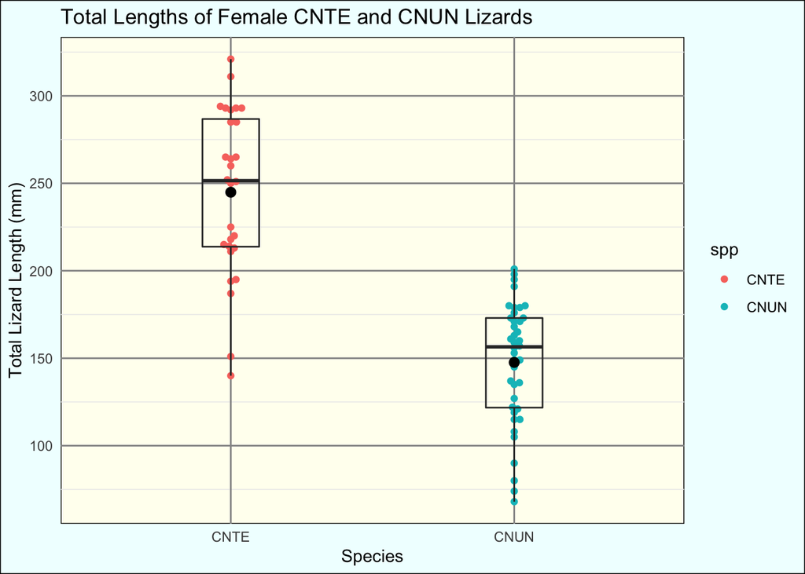

**Figure 1.** The distributions of female lizard lengths (mm) for CNTE (Cnemidophorus tessalatus, the Colorado Checkered lizard) and CNUN (Cnemidophorus uniparens, the Desert Grassland lizard) species at the Jornada Basin. Points indicate individual observations for total length (mm) of a female lizard. Box endpoints indicate the 25th and 75th percentile values; the black line and black point within the box indicate the median and mean value for each species, respectively. The CNTE female lizards tend to be longer than the CNUN female lizards on average.

**Table 1.** The following summary table contains the mean and standard deviation for total length (mm) and sample size for female CNTE lizards and female CNUN lizards.

| Species | Mean Female Lizard Length (mm) | Standard Deviation Female Lizard Length (mm) | Sample Size |
| --- | --- | --- | --- |
| CNTE | 244.9 | 47.3 | 28 |
| CNUN | 147.6 | 34.6 | 47 |

Mean total length for female CNTE lizards (244.9 mm) is greater than that for female CNUN lizards (147.6 mm); the actual difference in mean lengths between female CNTE lizards and female CNUN lizards is 97.3 mm. The effect size is large (Cohen’s *d* = 2.42). The t-test gives a p-value of 0 which means there is a 0% chance of finding sample means that are at least this different if drawn by random chance from populations with the same mean length.

### Data Citation

Lightfoot, D. 2017. Lizard pitfall trap data (LTER-II, LTER-III) ver 36. Environmental Data Initiative. https://doi.org/10.6073/pasta/ff37b4cace16a9943575f3fd7067064e.